# OTN/CANSSI Datathon: case study #

Keeler Colton

## Data availability statement

The dataset for this activity is available in the file “Annapolis River Striped Bass Keeler Colton 2023.csv” shared via Github (https://github.com/MarieAugerMethe/CANSSI_OTN_HMM_2023). It can used for our OTN/CANSSI meeting and shared for educational purposes with accreditation (Colton, KJ. 2023. Annapolis River Striped Bass Data subset). It cannot be used for any publication without written permission. Please contact Keeler Colton (keelercolton@acadiau.ca) for more information.

## Set up

Let’s load some of the packages needed.

```r
library(ggplot2)
library(lubridate)
```

## Description of the dataset

This dataset comes from an acoustic array (VR2W/VRTx) in the Annapolis River/Annapolis Basin in Nova Scotia. The data provided shows all detections occuring from May-September of 2023 for three sexually mature Striped Bass (Tag ID: 4168, 4169, 4170) tagged with V16T-4X acoustic transmitters (Innovasea) in Spring of 2023.

```r
bass <- read.csv("Keeler_Colton_Striped_Bass_2023.csv")
head(bass)
```

```
##          datetime tagid    temp      lat      long river.km
## 1 2023-05-18 0:12  4169 14.4556 44.83682 -65.27586     31.6
## 2 2023-05-18 0:14  4169 14.4556 44.83682 -65.27586     31.6
## 3 2023-05-18 0:15  4169 14.4556 44.83682 -65.27586     31.6
## 4 2023-05-18 0:16  4169 14.4556 44.83682 -65.27586     31.6
## 5 2023-05-18 0:17  4169 14.6125 44.83682 -65.27586     31.6
## 6 2023-05-18 0:18  4169 14.6125 44.83682 -65.27586     31.6
```

Specifically, the dataset we will use contain these variables:

- **datetime:** The date and time of detection
- **tagid:** The acoustic tag id of each individual (4168, 4169, 4170)
- **temp:** The temperature of the tag at each detection
- **lat:** The latitude of the receiver at each detection
- **long:** The longitude of the receiver at each detection
- **river.km** The distance of each receivers location in Kilometers upstream or downstream from a causeway at the rivers mouth (causeway = 0 km)

The main movement variable I would like to model is river.km. Think of this as a name given to the site of each receiver (river.km = 30? this receiver is located 30 kilometers upstream of the rivers mouth). Negative values are applied when downstream of rivers mouth.

There is no missing data from the three tagged individuals within the given time frame

## Quick data management and exploration

Let’s make id as a factor.

```r
bass$tagid <- as.factor(bass$tagid)
bass$datetime <- ymd_hm(bass$datetime)
```

Let’s quickly map the data.

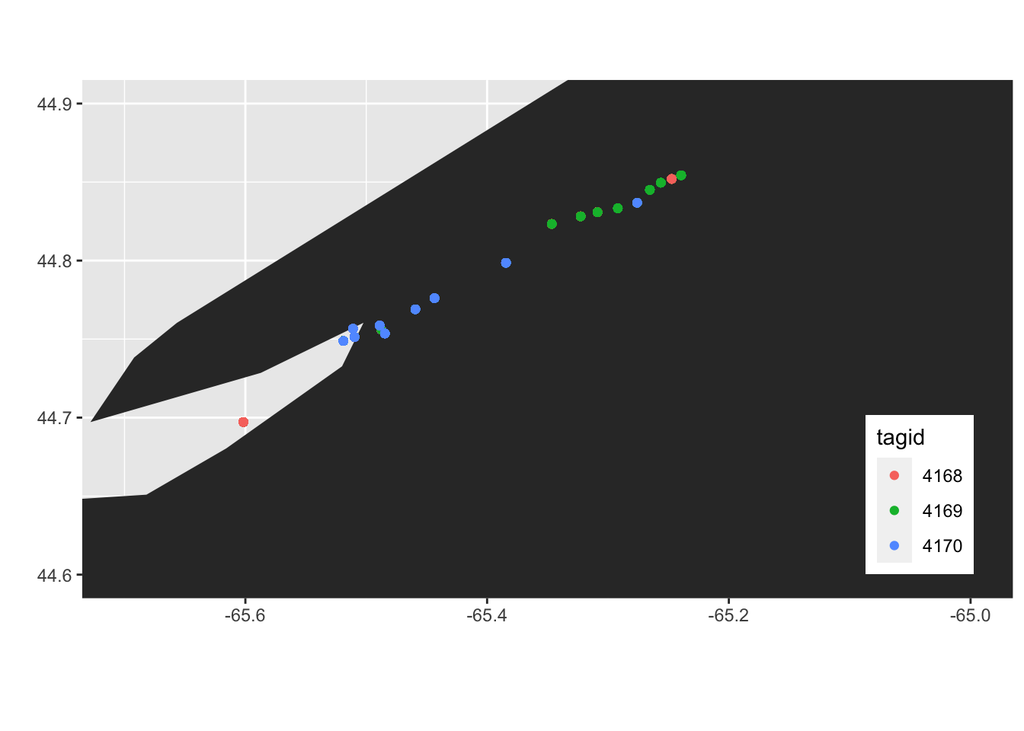

```r
# Get a world map
world <- map_data('world')

# Map the data
ggplot() +
  theme(legend.position = c(.9,.2)) +
  geom_polygon(data = world, aes(x=long, y = lat, group = group)) +
  coord_fixed(xlim=c(-65.7,-65), ylim=c(44.6,44.9), ratio=1.3) +
  xlab('') + ylab('') +
  geom_point(data = bass, aes(x=long, y=lat, colour = tagid))
```

Let’s look at the movement made along the river.

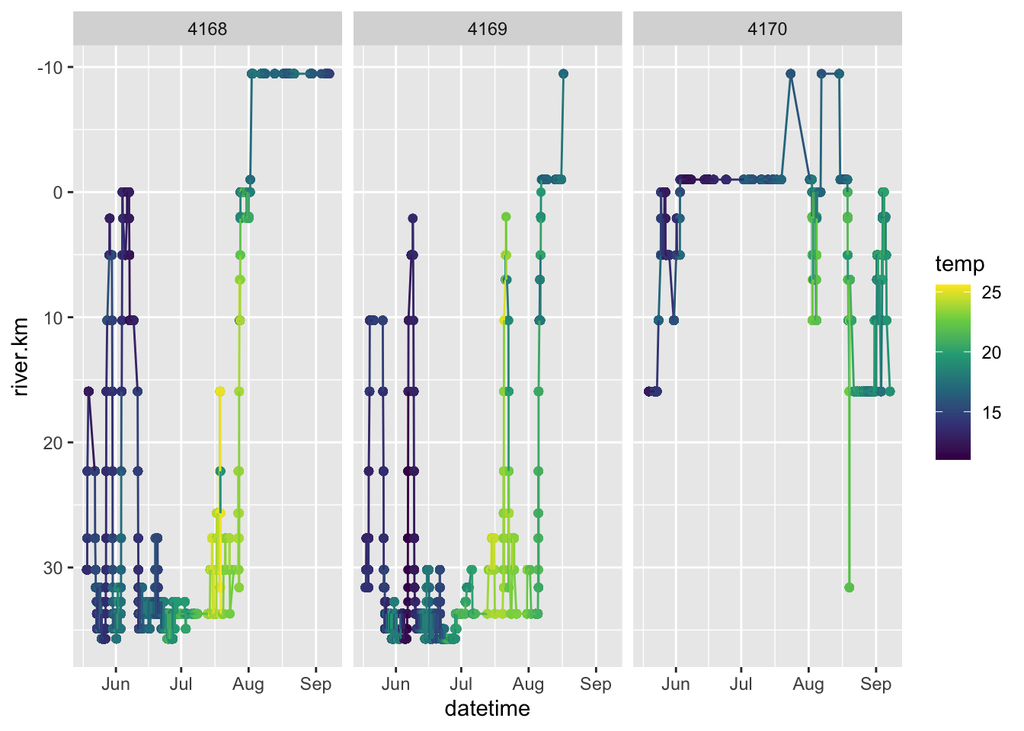

```r
ggplot(bass, aes(datetime, river.km, colour = temp)) +
  geom_point()+
  geom_line() +
  scale_color_viridis_c()+
  scale_y_reverse()+
  labs(colour = "temp") +
  facet_grid(~ tagid)
```

Let’s look at step length in terms of river km. This assumed that there is no missing data. Data will need to be regularized if there are missing data points.

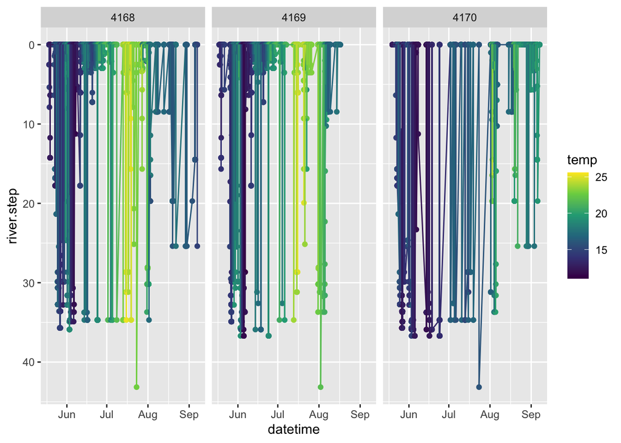

```r
# step, as in how much distance moved along the river (absolute values)
bass$river.step <- abs(c(diff(bass$river.km), NA))
# Could also look at directed step
#bass$river.step <- c(NA, diff(bass$river.km))

ggplot(bass, aes(datetime, river.step, colour = temp)) +
  geom_point() +
  geom_line() +
  scale_color_viridis_c()+
  scale_y_reverse()+
  labs(colour = "temp") +
  facet_grid(~ tagid)
```

## Datathon goal

The goals are (1) to provide a road map of how to tackle the questions listed below, (2) attempt to complete at least the first step of your road map, and (3) provide interpretation of the results. Make a quick 5-minute presentation explaining what your team did.

### Questions:

The Annapolis Spawning population of Striped Bass were declared extirpated by COSEWIC in 2011 after a tidal turbine was installed in the Annapolis Causeway in 1984 resulting is changes in the rivers hydrology and mortality. Striped Bass from other populations continued to seasonally occupy the river although successful spawning has not been documented in 30+ years. In 2019 the Turbine was decommissioned and the presence of non natal Striped Bass during the spawning season suggested possible re-colonization. The main goal of my work is to identify potential spawning in the river and overwintering behavior. In Canada, Striped Bass typically spawn in May above the head of tide (when in rivers) when water temperatures exceed 14.5 degrees Celsius. Spawning typically occurs in morning or evening on an outgoing tide and eggs drift downstream towards the ocean. Movement indicative of spawning behavior usually consists of movement from a staging ground (anywhere downstream of spawning ground, in this case lets go with >3 km) to the spawning ground which can be done repeatedly until environmental conditions are suitable for spawning. In 2023 I collected 3000 eggs when plankton netting on May 23rd at 14:00 at river.km 32.74 below the historical spawning grounds (river.km ~33-40). I would like to know if these three Striped Bass exhibit any spawning behavior and if so, were any on the spawning grounds prior to egg collection? if so, were temperatures suitable (i.e >14.5 degrees Celsius).

Since 2022 I have tagged 40 striped Bass in the River and believe there to be some contingent residency groups that reside in different parts of the watershed throughout June-September. I would like to classify these patterns in residency for these three fish as either: A - upstream fish (everything >25km), B - lower estuary fish (0-10km), and C - basin fish (everything <0)